# Bellabeat Markdown

Sean Bynum

2024-07-04

[figure not shown]

## The Scenario

You are a junior data analyst working on the marketing analyst team at Bellabeat, a high-tech manufacturer of health-focused products for women. Bellabeat is a successful small company, but they have the potential to become a larger player in the global smart device market. Urška Sršen, cofounder and Chief Creative Officer of Bellabeat, believes that analyzing smart device fitness data could help unlock new growth opportunities for the company. You have been asked to focus on one of Bellabeat’s products and analyze smart device data to gain insight into how consumers are using their smart devices.The insights you discover will then help guide marketing strategy for the company. You will present your analysis to the Bellabeat executive team along with your high-level recommendations for Bellabeat’s marketing strategy.

## The Products

- **Bellabeat app:** The Bellabeat app provides users with health data related to their activity, sleep, stress, menstrual cycle, and mindfulness habits. This data can help users better understand their current habits and make healthy decisions. The Bellabeat app connects to their line of smart wellness products.
- **Leaf:** Bellabeat’s classic wellness tracker can be worn as a bracelet, necklace, or clip. The Leaf tracker connects to the Bellabeat app to track activity, sleep, and stress.
- **Time:** This wellness watch combines the timeless look of a classic timepiece with smart technology to track user activity, sleep, and stress. The Time watch connects to the Bellabeat app to provide you with insights into your daily wellness.
- **Spring:** This is a water bottle that tracks daily water intake using smart technology to ensure that you are appropriately hydrated throughout the day. The Spring bottle connects to the Bellabeat app to track your hydration levels.
- **Bellabeat membership:** Bellabeat also offers a subscription-based membership program for users. Membership gives users 24/7 access to fully personalized guidance on nutrition, activity, sleep, health and beauty, and mindfulness based on their lifestyle and goals.

## The Ask

1. What are some trends in smart device usage?
2. How could these trends apply to Bellabeat customers?
3. How could these trends help influence Bellabeat marketing strategy?

## The Preparations

We are asked to use the data sets available at https://www.kaggle.com/datasets/arashnic/fitbit for the analysis. We are also encouraged to use supplemental data sets that could possibly help with the overall process.

## The Process

### Loading Up Tidyverse

```r
library(tidyverse)
```

```r
library(cowplot)
```

### Importing The Datasets

We then needed to import data sets we downloaded from Kaggle. I decided to use the ones below as I wanted to focus on a daily time frame rather than by the hour or minute. I also made the decision to add the weight log as weight is a keystone factor to overall health.

```r
daily_activity <- read_csv("dailyActivity_merged.csv")
daily_calories <- read_csv("dailyCalories_merged.csv")
daily_intensities <- read_csv("dailyIntensities_merged.csv")
daily_steps <- read_csv("dailySteps_merged.csv")
daily_sleep <- read_csv("sleepDay_merged.csv")
weight_log <- read_csv("weightLogInfo_merged.csv")
```

### Data Inspection

It was time to have a look at the data to see how it needed to be formatted. First, I wanted to look at the column names to see where our data frames overlap.

```r
head(daily_activity)
```

```
## # A tibble: 6 × 15
##           Id ActivityDate TotalSteps TotalDistance TrackerDistance
##        <dbl> <chr>             <dbl>         <dbl>           <dbl>
## 1 1503960366 4/12/2016         13162          8.5             8.5
## 2 1503960366 4/13/2016         10735          6.97            6.97
## 3 1503960366 4/14/2016         10460          6.74            6.74
## 4 1503960366 4/15/2016          9762          6.28            6.28
## 5 1503960366 4/16/2016         12669          8.16            8.16
## 6 1503960366 4/17/2016          9705          6.48            6.48
## # ℹ 10 more variables: LoggedActivitiesDistance <dbl>,
## #   VeryActiveDistance <dbl>, ModeratelyActiveDistance <dbl>,
## #   LightActiveDistance <dbl>, SedentaryActiveDistance <dbl>,
## #   VeryActiveMinutes <dbl>, FairlyActiveMinutes <dbl>,
## #   LightlyActiveMinutes <dbl>, SedentaryMinutes <dbl>, Calories <dbl>
```

```r
head(daily_calories)
```

```
## # A tibble: 6 × 3
##           Id ActivityDay Calories
##        <dbl> <chr>          <dbl>
## 1 1503960366 4/12/2016       1985
## 2 1503960366 4/13/2016       1797
## 3 1503960366 4/14/2016       1776
## 4 1503960366 4/15/2016       1745
## 5 1503960366 4/16/2016       1863
## 6 1503960366 4/17/2016       1728
```

```r
head(daily_intensities)
```

```
## # A tibble: 6 × 10
##         Id ActivityDay SedentaryMinutes LightlyActiveMinutes FairlyActiveMinutes
##      <dbl> <chr>                  <dbl>                <dbl>               <dbl>
## 1   1.50e9 4/12/2016                728                  328                  13
## 2   1.50e9 4/13/2016                776                  217                  19
## 3   1.50e9 4/14/2016               1218                  181                  11
## 4   1.50e9 4/15/2016                726                  209                  34
## 5   1.50e9 4/16/2016                773                  221                  10
## 6   1.50e9 4/17/2016                539                  164                  20
## # ℹ 5 more variables: VeryActiveMinutes <dbl>, SedentaryActiveDistance <dbl>,
## #   LightActiveDistance <dbl>, ModeratelyActiveDistance <dbl>,
## #   VeryActiveDistance <dbl>
```

```r
head(daily_steps)
```

```
## # A tibble: 6 × 3
##           Id ActivityDay StepTotal
##        <dbl> <chr>           <dbl>
## 1 1503960366 4/12/2016       13162
## 2 1503960366 4/13/2016       10735
## 3 1503960366 4/14/2016       10460
## 4 1503960366 4/15/2016        9762
## 5 1503960366 4/16/2016       12669
## 6 1503960366 4/17/2016        9705
```

```r
head(daily_sleep)
```

```
## # A tibble: 6 × 5
##           Id SleepDay        TotalSleepRecords TotalMinutesAsleep TotalTimeInBed
##        <dbl> <chr>                       <dbl>              <dbl>          <dbl>
## 1 1503960366 4/12/2016 12:0…                 1                327            346
## 2 1503960366 4/13/2016 12:0…                 2                384            407
## 3 1503960366 4/15/2016 12:0…                 1                412            442
## 4 1503960366 4/16/2016 12:0…                 2                340            367
## 5 1503960366 4/17/2016 12:0…                 1                700            712
## 6 1503960366 4/19/2016 12:0…                 1                304            320
```

```r
head(weight_log)
```

```
## # A tibble: 6 × 8
##           Id Date       WeightKg WeightPounds   Fat   BMI IsManualReport   LogId
##        <dbl> <chr>         <dbl>        <dbl> <dbl> <dbl> <lgl>            <dbl>
## 1 1503960366 5/2/2016 …     52.6         116.    22  22.6 TRUE           1.46e12
## 2 1503960366 5/3/2016 …     52.6         116.    NA  22.6 TRUE           1.46e12
## 3 1927972279 4/13/2016…    134.          294.    NA  47.5 FALSE          1.46e12
## 4 2873212765 4/21/2016…     56.7         125.    NA  21.5 TRUE           1.46e12
## 5 2873212765 5/12/2016…     57.3         126.    NA  21.7 TRUE           1.46e12
## 6 4319703577 4/17/2016…     72.4         160.    25  27.5 TRUE           1.46e12
```

I then decided to check the structure of the data frames to see if any needed to be changed so that overlapping columns can be merged.

```r
str(daily_activity)
```

```
## spc_tbl_ [940 × 15] (S3: spec_tbl_df/tbl_df/tbl/data.frame)
##  $ Id                      : num [1:940] 1.5e+09 1.5e+09 1.5e+09 1.5e+09 1.5e+09 ...
##  $ ActivityDate            : chr [1:940] "4/12/2016" "4/13/2016" "4/14/2016" "4/15/2016" ...
##  $ TotalSteps              : num [1:940] 13162 10735 10460 9762 12669 ...
##  $ TotalDistance           : num [1:940] 8.5 6.97 6.74 6.28 8.16 ...
##  $ TrackerDistance         : num [1:940] 8.5 6.97 6.74 6.28 8.16 ...
##  $ LoggedActivitiesDistance: num [1:940] 0 0 0 0 0 0 0 0 0 0 ...
##  $ VeryActiveDistance      : num [1:940] 1.88 1.57 2.44 2.14 2.71 ...
##  $ ModeratelyActiveDistance: num [1:940] 0.55 0.69 0.4 1.26 0.41 ...
##  $ LightActiveDistance     : num [1:940] 6.06 4.71 3.91 2.83 5.04 ...
##  $ SedentaryActiveDistance : num [1:940] 0 0 0 0 0 0 0 0 0 0 ...
##  $ VeryActiveMinutes       : num [1:940] 25 21 30 29 36 38 42 50 28 19 ...
##  $ FairlyActiveMinutes     : num [1:940] 13 19 11 34 10 20 16 31 12 8 ...
##  $ LightlyActiveMinutes    : num [1:940] 328 217 181 209 221 164 233 264 205 211 ...
##  $ SedentaryMinutes        : num [1:940] 728 776 1218 726 773 ...
##  $ Calories                : num [1:940] 1985 1797 1776 1745 1863 ...
##  - attr(*, "spec")=
##   .. cols(
##   ..   Id = col_double(),
##   ..   ActivityDate = col_character(),
##   ..   TotalSteps = col_double(),
##   ..   TotalDistance = col_double(),
##   ..   TrackerDistance = col_double(),
##   ..   LoggedActivitiesDistance = col_double(),
##   ..   VeryActiveDistance = col_double(),
##   ..   ModeratelyActiveDistance = col_double(),
##   ..   LightActiveDistance = col_double(),
##   ..   SedentaryActiveDistance = col_double(),
##   ..   VeryActiveMinutes = col_double(),
##   ..   FairlyActiveMinutes = col_double(),
##   ..   LightlyActiveMinutes = col_double(),
##   ..   SedentaryMinutes = col_double(),
##   ..   Calories = col_double()
##   .. )
##  - attr(*, "problems")=<externalptr>
```

```r
str(daily_calories)
```

```
## spc_tbl_ [940 × 3] (S3: spec_tbl_df/tbl_df/tbl/data.frame)
##  $ Id         : num [1:940] 1.5e+09 1.5e+09 1.5e+09 1.5e+09 1.5e+09 ...
##  $ ActivityDay: chr [1:940] "4/12/2016" "4/13/2016" "4/14/2016" "4/15/2016" ...
##  $ Calories   : num [1:940] 1985 1797 1776 1745 1863 ...
##  - attr(*, "spec")=
##   .. cols(
##   ..   Id = col_double(),
##   ..   ActivityDay = col_character(),
##   ..   Calories = col_double()
##   .. )
##  - attr(*, "problems")=<externalptr>
```

```r
str(daily_intensities)
```

```
## spc_tbl_ [940 × 10] (S3: spec_tbl_df/tbl_df/tbl/data.frame)
##  $ Id                      : num [1:940] 1.5e+09 1.5e+09 1.5e+09 1.5e+09 1.5e+09 ...
##  $ ActivityDay             : chr [1:940] "4/12/2016" "4/13/2016" "4/14/2016" "4/15/2016" ...
##  $ SedentaryMinutes        : num [1:940] 728 776 1218 726 773 ...
##  $ LightlyActiveMinutes    : num [1:940] 328 217 181 209 221 164 233 264 205 211 ...
##  $ FairlyActiveMinutes     : num [1:940] 13 19 11 34 10 20 16 31 12 8 ...
##  $ VeryActiveMinutes       : num [1:940] 25 21 30 29 36 38 42 50 28 19 ...
##  $ SedentaryActiveDistance : num [1:940] 0 0 0 0 0 0 0 0 0 0 ...
##  $ LightActiveDistance     : num [1:940] 6.06 4.71 3.91 2.83 5.04 ...
##  $ ModeratelyActiveDistance: num [1:940] 0.55 0.69 0.4 1.26 0.41 ...
##  $ VeryActiveDistance      : num [1:940] 1.88 1.57 2.44 2.14 2.71 ...
##  - attr(*, "spec")=
##   .. cols(
##   ..   Id = col_double(),
##   ..   ActivityDay = col_character(),
##   ..   SedentaryMinutes = col_double(),
##   ..   LightlyActiveMinutes = col_double(),
##   ..   FairlyActiveMinutes = col_double(),
##   ..   VeryActiveMinutes = col_double(),
##   ..   SedentaryActiveDistance = col_double(),
##   ..   LightActiveDistance = col_double(),
##   ..   ModeratelyActiveDistance = col_double(),
##   ..   VeryActiveDistance = col_double()
##   .. )
##  - attr(*, "problems")=<externalptr>
```

```r
str(daily_steps)
```

```
## spc_tbl_ [940 × 3] (S3: spec_tbl_df/tbl_df/tbl/data.frame)
##  $ Id         : num [1:940] 1.5e+09 1.5e+09 1.5e+09 1.5e+09 1.5e+09 ...
##  $ ActivityDay: chr [1:940] "4/12/2016" "4/13/2016" "4/14/2016" "4/15/2016" ...
##  $ StepTotal  : num [1:940] 13162 10735 10460 9762 12669 ...
##  - attr(*, "spec")=
##   .. cols(
##   ..   Id = col_double(),
##   ..   ActivityDay = col_character(),
##   ..   StepTotal = col_double()
##   .. )
##  - attr(*, "problems")=<externalptr>
```

```r
str(daily_sleep)
```

```
## spc_tbl_ [413 × 5] (S3: spec_tbl_df/tbl_df/tbl/data.frame)
##  $ Id                : num [1:413] 1.5e+09 1.5e+09 1.5e+09 1.5e+09 1.5e+09 ...
##  $ SleepDay          : chr [1:413] "4/12/2016 12:00:00 AM" "4/13/2016 12:00:00 AM" "4/15/2016 12:00:00 AM" "4/16/2016 12:00:00 AM" ...
##  $ TotalSleepRecords : num [1:413] 1 2 1 2 1 1 1 1 1 1 ...
##  $ TotalMinutesAsleep: num [1:413] 327 384 412 340 700 304 360 325 361 430 ...
##  $ TotalTimeInBed    : num [1:413] 346 407 442 367 712 320 377 364 384 449 ...
##  - attr(*, "spec")=
##   .. cols(
##   ..   Id = col_double(),
##   ..   SleepDay = col_character(),
##   ..   TotalSleepRecords = col_double(),
##   ..   TotalMinutesAsleep = col_double(),
##   ..   TotalTimeInBed = col_double()
##   .. )
##  - attr(*, "problems")=<externalptr>
```

```r
str(weight_log)
```

```
## spc_tbl_ [67 × 8] (S3: spec_tbl_df/tbl_df/tbl/data.frame)
##  $ Id            : num [1:67] 1.50e+09 1.50e+09 1.93e+09 2.87e+09 2.87e+09 ...
##  $ Date          : chr [1:67] "5/2/2016 11:59:59 PM" "5/3/2016 11:59:59 PM" "4/13/2016 1:08:52 AM" "4/21/2016 11:59:59 PM" ...
##  $ WeightKg      : num [1:67] 52.6 52.6 133.5 56.7 57.3 ...
##  $ WeightPounds  : num [1:67] 116 116 294 125 126 ...
##  $ Fat           : num [1:67] 22 NA NA NA NA 25 NA NA NA NA ...
##  $ BMI           : num [1:67] 22.6 22.6 47.5 21.5 21.7 ...
##  $ IsManualReport: logi [1:67] TRUE TRUE FALSE TRUE TRUE TRUE ...
##  $ LogId         : num [1:67] 1.46e+12 1.46e+12 1.46e+12 1.46e+12 1.46e+12 ...
##  - attr(*, "spec")=
##   .. cols(
##   ..   Id = col_double(),
##   ..   Date = col_character(),
##   ..   WeightKg = col_double(),
##   ..   WeightPounds = col_double(),
##   ..   Fat = col_double(),
##   ..   BMI = col_double(),
##   ..   IsManualReport = col_logical(),
##   ..   LogId = col_double()
##   .. )
##  - attr(*, "problems")=<externalptr>
```

We can clearly see that they all share the “ID” Column. I wanted to then see how many unique ones are in each of the data frames.

```r
n_distinct(daily_activity$Id)
```

```
## [1] 33
```

```r
n_distinct(daily_calories$Id)
```

```
## [1] 33
```

```r
n_distinct(daily_intensities$Id)
```

```
## [1] 33
```

```r
n_distinct(daily_steps$Id)
```

```
## [1] 33
```

```r
n_distinct(daily_sleep$Id)
```

```
## [1] 24
```

```r
n_distinct(weight_log$Id)
```

```
## [1] 8
```

### Cleaning the Data

Duplicates and NA rows were removed.It became apparent after this step that the daily_calories, daily_intensities, and daily_steps data frames did not provide any unique data columns or rows that weren’t already in the daily_activity data frame. I suspected this, however, I wanted to be sure. They were no longer needed to proceed.

```r
daily_activity <- daily_activity %>%
  distinct() %>%
  drop_na()

daily_calories <- daily_calories %>%
  distinct() %>%
  drop_na()

daily_intensities <- daily_intensities %>%
  distinct() %>%
  drop_na()

daily_steps <- daily_steps %>%
  distinct() %>%
  drop_na()

daily_sleep <- daily_sleep %>%
  distinct() %>%
  drop_na()

weight_log <- weight_log %>%
  distinct()
```

### Renaming/Reformatting the Data

Changed the names and formats for columns in each data frame for uniformity.

```r
daily_activity <- daily_activity %>%
  mutate(ActivityDate = as_date(ActivityDate, format = "%m/%d/%Y"))

daily_sleep <- daily_sleep %>%
  rename (ActivityDate = SleepDay) %>%
  mutate(ActivityDate = as_date(ActivityDate, format = "%m/%d/%Y %I:%M:%S %p"))

weight_log <- weight_log %>%
  rename (ActivityDate = Date) %>%
mutate(ActivityDate = as.POSIXct(ActivityDate, format = "%m/%d/%Y %I:%M:%S %p", tz=Sys.timezone())) %>%
  separate(ActivityDate,into=c("ActivityDate","Time"),sep=" ") %>%
  mutate(ActivityDate = as_date(ActivityDate))
```

### Summaraizing Each Data Frame

It was time to take a large scope look at all the data frames.

```r
summary(daily_activity)
```

```
##        Id             ActivityDate          TotalSteps    TotalDistance
##  Min.   :1.504e+09   Min.   :2016-04-12   Min.   :    0   Min.   : 0.000
##  1st Qu.:2.320e+09   1st Qu.:2016-04-19   1st Qu.: 3790   1st Qu.: 2.620
##  Median :4.445e+09   Median :2016-04-26   Median : 7406   Median : 5.245
##  Mean   :4.855e+09   Mean   :2016-04-26   Mean   : 7638   Mean   : 5.490
##  3rd Qu.:6.962e+09   3rd Qu.:2016-05-04   3rd Qu.:10727   3rd Qu.: 7.713
##  Max.   :8.878e+09   Max.   :2016-05-12   Max.   :36019   Max.   :28.030
##  TrackerDistance  LoggedActivitiesDistance VeryActiveDistance
##  Min.   : 0.000   Min.   :0.0000           Min.   : 0.000
##  1st Qu.: 2.620   1st Qu.:0.0000           1st Qu.: 0.000
##  Median : 5.245   Median :0.0000           Median : 0.210
##  Mean   : 5.475   Mean   :0.1082           Mean   : 1.503
##  3rd Qu.: 7.710   3rd Qu.:0.0000           3rd Qu.: 2.053
##  Max.   :28.030   Max.   :4.9421           Max.   :21.920
##  ModeratelyActiveDistance LightActiveDistance SedentaryActiveDistance
##  Min.   :0.0000           Min.   : 0.000      Min.   :0.000000
##  1st Qu.:0.0000           1st Qu.: 1.945      1st Qu.:0.000000
##  Median :0.2400           Median : 3.365      Median :0.000000
##  Mean   :0.5675           Mean   : 3.341      Mean   :0.001606
##  3rd Qu.:0.8000           3rd Qu.: 4.782      3rd Qu.:0.000000
##  Max.   :6.4800           Max.   :10.710      Max.   :0.110000
##  VeryActiveMinutes FairlyActiveMinutes LightlyActiveMinutes SedentaryMinutes
##  Min.   :  0.00    Min.   :  0.00      Min.   :  0.0        Min.   :   0.0
##  1st Qu.:  0.00    1st Qu.:  0.00      1st Qu.:127.0        1st Qu.: 729.8
##  Median :  4.00    Median :  6.00      Median :199.0        Median :1057.5
##  Mean   : 21.16    Mean   : 13.56      Mean   :192.8        Mean   : 991.2
##  3rd Qu.: 32.00    3rd Qu.: 19.00      3rd Qu.:264.0        3rd Qu.:1229.5
##  Max.   :210.00    Max.   :143.00      Max.   :518.0        Max.   :1440.0
##     Calories
##  Min.   :   0
##  1st Qu.:1828
##  Median :2134
##  Mean   :2304
##  3rd Qu.:2793
##  Max.   :4900
```

```r
summary(daily_sleep)
```

```
##        Id             ActivityDate        TotalSleepRecords TotalMinutesAsleep
##  Min.   :1.504e+09   Min.   :2016-04-12   Min.   :1.00      Min.   : 58.0
##  1st Qu.:3.977e+09   1st Qu.:2016-04-19   1st Qu.:1.00      1st Qu.:361.0
##  Median :4.703e+09   Median :2016-04-27   Median :1.00      Median :432.5
##  Mean   :4.995e+09   Mean   :2016-04-26   Mean   :1.12      Mean   :419.2
##  3rd Qu.:6.962e+09   3rd Qu.:2016-05-04   3rd Qu.:1.00      3rd Qu.:490.0
##  Max.   :8.792e+09   Max.   :2016-05-12   Max.   :3.00      Max.   :796.0
##  TotalTimeInBed
##  Min.   : 61.0
##  1st Qu.:403.8
##  Median :463.0
##  Mean   :458.5
##  3rd Qu.:526.0
##  Max.   :961.0
```

```r
summary(weight_log)
```

```
##        Id             ActivityDate            Time              WeightKg
##  Min.   :1.504e+09   Min.   :2016-04-12   Length:67          Min.   : 52.60
##  1st Qu.:6.962e+09   1st Qu.:2016-04-19   Class :character   1st Qu.: 61.40
##  Median :6.962e+09   Median :2016-04-27   Mode  :character   Median : 62.50
##  Mean   :7.009e+09   Mean   :2016-04-26                      Mean   : 72.04
##  3rd Qu.:8.878e+09   3rd Qu.:2016-05-04                      3rd Qu.: 85.05
##  Max.   :8.878e+09   Max.   :2016-05-12                      Max.   :133.50
##
##   WeightPounds        Fat             BMI        IsManualReport
##  Min.   :116.0   Min.   :22.00   Min.   :21.45   Mode :logical
##  1st Qu.:135.4   1st Qu.:22.75   1st Qu.:23.96   FALSE:26
##  Median :137.8   Median :23.50   Median :24.39   TRUE :41
##  Mean   :158.8   Mean   :23.50   Mean   :25.19
##  3rd Qu.:187.5   3rd Qu.:24.25   3rd Qu.:25.56
##  Max.   :294.3   Max.   :25.00   Max.   :47.54
##                  NA's   :65
##      LogId
##  Min.   :1.460e+12
##  1st Qu.:1.461e+12
##  Median :1.462e+12
##  Mean   :1.462e+12
##  3rd Qu.:1.462e+12
##  Max.   :1.463e+12
##
```

### Merging the Data

It was time to merge the data frames for different analyses. I wanted to see the relationship between the activity and sleep variables to observe any possible correlations when merging the two data frames. I also wanted to merge all the data frames that share the same observations but with different variables.

```r
activity_sleep_merged <- merge(daily_sleep, daily_activity, by = c("Id", "ActivityDate"))

weight_activity_sleep_merged <- merge(weight_log, activity_sleep_merged, by = c("Id", "ActivityDate"))
```

I also wanted to add a “month” and “day of the week column” based on the ActivityDate column for each data frame.

Additionally, I wanted to see averages of different areas broken down by day.

## The Analysis

It was time to finally make some observations of the cleaned and merged data frames. I first wanted to look at the summary of each. I was also interested in having a look at how many unique participants logged everything including their weight.

```r
summary(daily_activity)
```

```
##        Id             ActivityDate          TotalSteps    TotalDistance
##  Min.   :1.504e+09   Min.   :2016-04-12   Min.   :    0   Min.   : 0.000
##  1st Qu.:2.320e+09   1st Qu.:2016-04-19   1st Qu.: 3790   1st Qu.: 2.620
##  Median :4.445e+09   Median :2016-04-26   Median : 7406   Median : 5.245
##  Mean   :4.855e+09   Mean   :2016-04-26   Mean   : 7638   Mean   : 5.490
##  3rd Qu.:6.962e+09   3rd Qu.:2016-05-04   3rd Qu.:10727   3rd Qu.: 7.713
##  Max.   :8.878e+09   Max.   :2016-05-12   Max.   :36019   Max.   :28.030
##  TrackerDistance  LoggedActivitiesDistance VeryActiveDistance
##  Min.   : 0.000   Min.   :0.0000           Min.   : 0.000
##  1st Qu.: 2.620   1st Qu.:0.0000           1st Qu.: 0.000
##  Median : 5.245   Median :0.0000           Median : 0.210
##  Mean   : 5.475   Mean   :0.1082           Mean   : 1.503
##  3rd Qu.: 7.710   3rd Qu.:0.0000           3rd Qu.: 2.053
##  Max.   :28.030   Max.   :4.9421           Max.   :21.920
##  ModeratelyActiveDistance LightActiveDistance SedentaryActiveDistance
##  Min.   :0.0000           Min.   : 0.000      Min.   :0.000000
##  1st Qu.:0.0000           1st Qu.: 1.945      1st Qu.:0.000000
##  Median :0.2400           Median : 3.365      Median :0.000000
##  Mean   :0.5675           Mean   : 3.341      Mean   :0.001606
##  3rd Qu.:0.8000           3rd Qu.: 4.782      3rd Qu.:0.000000
##  Max.   :6.4800           Max.   :10.710      Max.   :0.110000
##  VeryActiveMinutes FairlyActiveMinutes LightlyActiveMinutes SedentaryMinutes
##  Min.   :  0.00    Min.   :  0.00      Min.   :  0.0        Min.   :   0.0
##  1st Qu.:  0.00    1st Qu.:  0.00      1st Qu.:127.0        1st Qu.: 729.8
##  Median :  4.00    Median :  6.00      Median :199.0        Median :1057.5
##  Mean   : 21.16    Mean   : 13.56      Mean   :192.8        Mean   : 991.2
##  3rd Qu.: 32.00    3rd Qu.: 19.00      3rd Qu.:264.0        3rd Qu.:1229.5
##  Max.   :210.00    Max.   :143.00      Max.   :518.0        Max.   :1440.0
##     Calories       Month            DayofWeek
##  Min.   :   0   Length:940         Length:940
##  1st Qu.:1828   Class :character   Class :character
##  Median :2134   Mode  :character   Mode  :character
##  Mean   :2304
##  3rd Qu.:2793
##  Max.   :4900
```

```r
summary(activity_sleep_merged)
```

```
##        Id             ActivityDate        TotalSleepRecords TotalMinutesAsleep
##  Min.   :1.504e+09   Min.   :2016-04-12   Min.   :1.00      Min.   : 58.0
##  1st Qu.:3.977e+09   1st Qu.:2016-04-19   1st Qu.:1.00      1st Qu.:361.0
##  Median :4.703e+09   Median :2016-04-27   Median :1.00      Median :432.5
##  Mean   :4.995e+09   Mean   :2016-04-26   Mean   :1.12      Mean   :419.2
##  3rd Qu.:6.962e+09   3rd Qu.:2016-05-04   3rd Qu.:1.00      3rd Qu.:490.0
##  Max.   :8.792e+09   Max.   :2016-05-12   Max.   :3.00      Max.   :796.0
##  TotalTimeInBed    TotalSteps    TotalDistance    TrackerDistance
##  Min.   : 61.0   Min.   :   17   Min.   : 0.010   Min.   : 0.010
##  1st Qu.:403.8   1st Qu.: 5189   1st Qu.: 3.592   1st Qu.: 3.592
##  Median :463.0   Median : 8913   Median : 6.270   Median : 6.270
##  Mean   :458.5   Mean   : 8515   Mean   : 6.012   Mean   : 6.007
##  3rd Qu.:526.0   3rd Qu.:11370   3rd Qu.: 8.005   3rd Qu.: 7.950
##  Max.   :961.0   Max.   :22770   Max.   :17.540   Max.   :17.540
##  LoggedActivitiesDistance VeryActiveDistance ModeratelyActiveDistance
##  Min.   :0.0000           Min.   : 0.000     Min.   :0.0000
##  1st Qu.:0.0000           1st Qu.: 0.000     1st Qu.:0.0000
##  Median :0.0000           Median : 0.570     Median :0.4200
##  Mean   :0.1089           Mean   : 1.446     Mean   :0.7439
##  3rd Qu.:0.0000           3rd Qu.: 2.360     3rd Qu.:1.0375
##  Max.   :4.0817           Max.   :12.540     Max.   :6.4800
##  LightActiveDistance SedentaryActiveDistance VeryActiveMinutes
##  Min.   :0.010       Min.   :0.0000000       Min.   :  0.00
##  1st Qu.:2.540       1st Qu.:0.0000000       1st Qu.:  0.00
##  Median :3.665       Median :0.0000000       Median :  9.00
##  Mean   :3.791       Mean   :0.0009268       Mean   : 25.05
##  3rd Qu.:4.918       3rd Qu.:0.0000000       3rd Qu.: 38.00
##  Max.   :9.480       Max.   :0.1100000       Max.   :210.00
##  FairlyActiveMinutes LightlyActiveMinutes SedentaryMinutes    Calories
##  Min.   :  0.00      Min.   :  2.0        Min.   :   0.0   Min.   : 257
##  1st Qu.:  0.00      1st Qu.:158.0        1st Qu.: 631.2   1st Qu.:1841
##  Median : 11.00      Median :208.0        Median : 717.0   Median :2207
##  Mean   : 17.92      Mean   :216.5        Mean   : 712.1   Mean   :2389
##  3rd Qu.: 26.75      3rd Qu.:263.0        3rd Qu.: 782.8   3rd Qu.:2920
##  Max.   :143.00      Max.   :518.0        Max.   :1265.0   Max.   :4900
##     Month            DayofWeek
##  Length:410         Length:410
##  Class :character   Class :character
##  Mode  :character   Mode  :character
##
##
##
```

```r
summary(weight_activity_sleep_merged)
```

```
##        Id             ActivityDate            Time              WeightKg
##  Min.   :1.504e+09   Min.   :2016-04-12   Length:35          Min.   : 52.60
##  1st Qu.:6.962e+09   1st Qu.:2016-04-18   Class :character   1st Qu.: 61.20
##  Median :6.962e+09   Median :2016-04-28   Mode  :character   Median : 61.50
##  Mean   :6.398e+09   Mean   :2016-04-26                      Mean   : 64.17
##  3rd Qu.:6.962e+09   3rd Qu.:2016-05-03                      3rd Qu.: 61.90
##  Max.   :6.962e+09   Max.   :2016-05-12                      Max.   :133.50
##
##   WeightPounds        Fat          BMI        IsManualReport
##  Min.   :116.0   Min.   :22   Min.   :22.65   Mode :logical
##  1st Qu.:134.9   1st Qu.:22   1st Qu.:23.89   FALSE:2
##  Median :135.6   Median :22   Median :24.00   TRUE :33
##  Mean   :141.5   Mean   :22   Mean   :24.83
##  3rd Qu.:136.5   3rd Qu.:22   3rd Qu.:24.17
##  Max.   :294.3   Max.   :22   Max.   :47.54
##                  NA's   :34
##      LogId           TotalSleepRecords TotalMinutesAsleep TotalTimeInBed
##  Min.   :1.461e+12   Min.   :1.000     Min.   :115.0      Min.   :129.0
##  1st Qu.:1.461e+12   1st Qu.:1.000     1st Qu.:399.0      1st Qu.:420.0
##  Median :1.462e+12   Median :1.000     Median :442.0      Median :455.0
##  Mean   :1.462e+12   Mean   :1.086     Mean   :430.3      Mean   :449.8
##  3rd Qu.:1.462e+12   3rd Qu.:1.000     3rd Qu.:472.5      3rd Qu.:494.0
##  Max.   :1.463e+12   Max.   :3.000     Max.   :630.0      Max.   :679.0
##
##    TotalSteps    TotalDistance    TrackerDistance  LoggedActivitiesDistance
##  Min.   :  356   Min.   : 0.250   Min.   : 0.250   Min.   :0.0000
##  1st Qu.: 5780   1st Qu.: 3.825   1st Qu.: 3.825   1st Qu.:0.0000
##  Median :10524   Median : 6.960   Median : 6.960   Median :0.0000
##  Mean   : 9687   Mean   : 6.523   Mean   : 6.464   Mean   :0.2867
##  3rd Qu.:12484   3rd Qu.: 8.730   3rd Qu.: 8.610   3rd Qu.:0.0000
##  Max.   :20031   Max.   :13.240   Max.   :13.240   Max.   :4.0817
##
##  VeryActiveDistance ModeratelyActiveDistance LightActiveDistance
##  Min.   :0.000      Min.   :0.0000           Min.   :0.25
##  1st Qu.:0.000      1st Qu.:0.1900           1st Qu.:2.76
##  Median :1.200      Median :0.7600           Median :3.91
##  Mean   :1.727      Mean   :0.9083           Mean   :3.88
##  3rd Qu.:3.305      3rd Qu.:1.6800           3rd Qu.:4.88
##  Max.   :5.980      Max.   :2.3900           Max.   :7.04
##
```

[output cut: 9 more lines]

```
##  Min.   : 32.0        Min.   : 127.0   Min.   : 928   Length:35
##  1st Qu.:197.0        1st Qu.: 635.5   1st Qu.:1852   Class :character
##  Median :240.0        Median : 689.0   Median :2039   Mode  :character
##  Mean   :236.5        Mean   : 688.5   Mean   :2052
##  3rd Qu.:286.0        3rd Qu.: 736.0   3rd Qu.:2168
##  Max.   :369.0        Max.   :1121.0   Max.   :4552
##
##   DayofWeek
##  Length:35
##  Class :character
##  Mode  :character
##
##
##
##
```

```r
n_distinct(weight_activity_sleep_merged$Id)
```

```
## [1] 5
```

```r
n_distinct(activity_sleep_merged$Id)
```

```
## [1] 24
```

### Initial Observations

- Participants would be considered “lightly active” on average based on active minutes.
- Participants are non-active for 16.5 hours per day on average.
- Participants get 7 hours of sleep per day on average.
- Participants spend 7 hours and 38 minutes in bed on average.
- Participants take approximately 7638 steps per day on average.
- Participants burn 2304 calories per day on average.
- Only 8 participants logged their weight. Of the 8, only 5 also logged their activity and sleep.

### Hypotheses

- The more active the participants are, the more calories they will burn.
- The higher the step count, the higher the calorie burn per day.
- Weekdays will yield a higher average calorie burn rate than weekends.
- Sunday will likely yield the lowest activity and highest sleep rate on average.

### Data Plotting

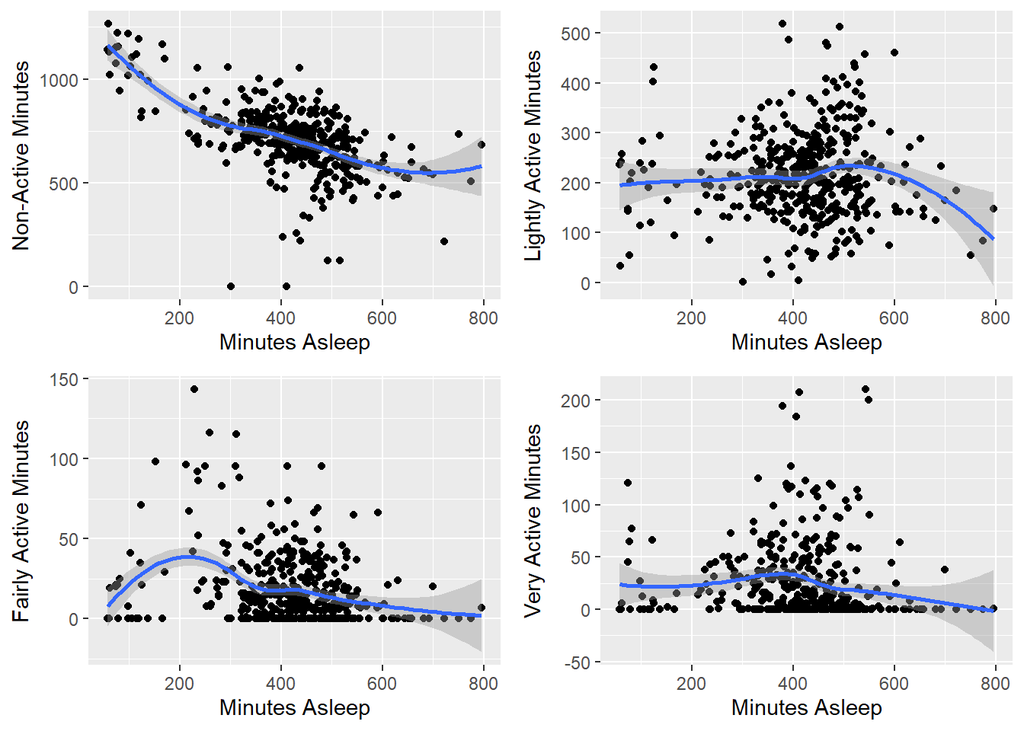

I wanted to have a look at this first as I was curious to see if there was any correlation between activity level and if it had an impact on the amount of sleep participants received after. This analysis shows possible correlation but extensive data beyond the scope of this project would be needed.

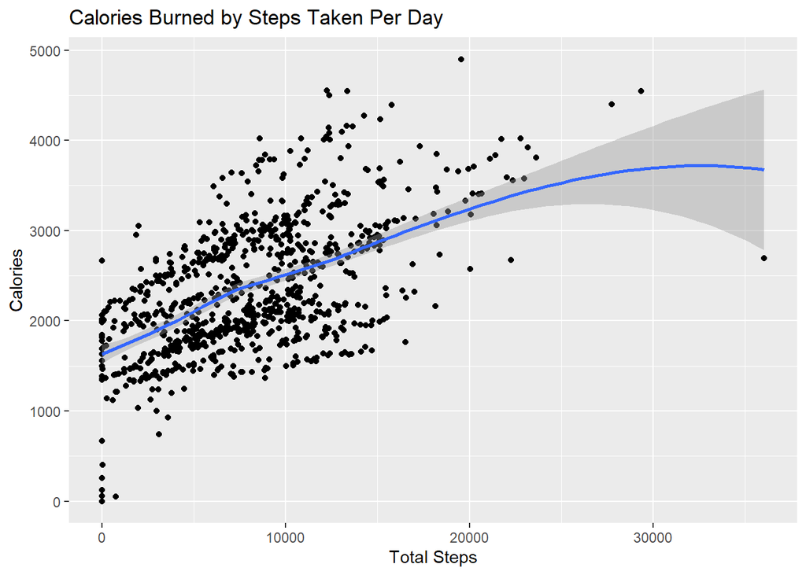

There is a direct, positive correlation between calories burned and total steps taken per day. The more steps taken the more calories burned.

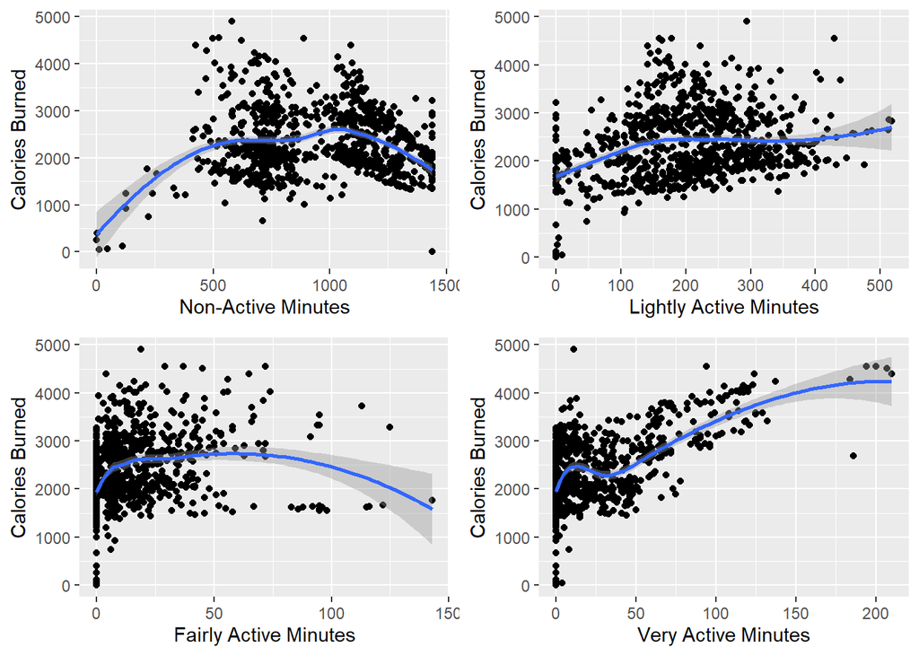

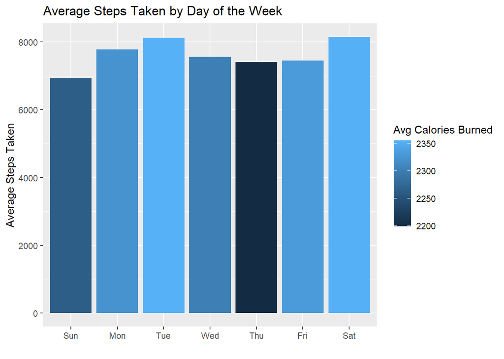

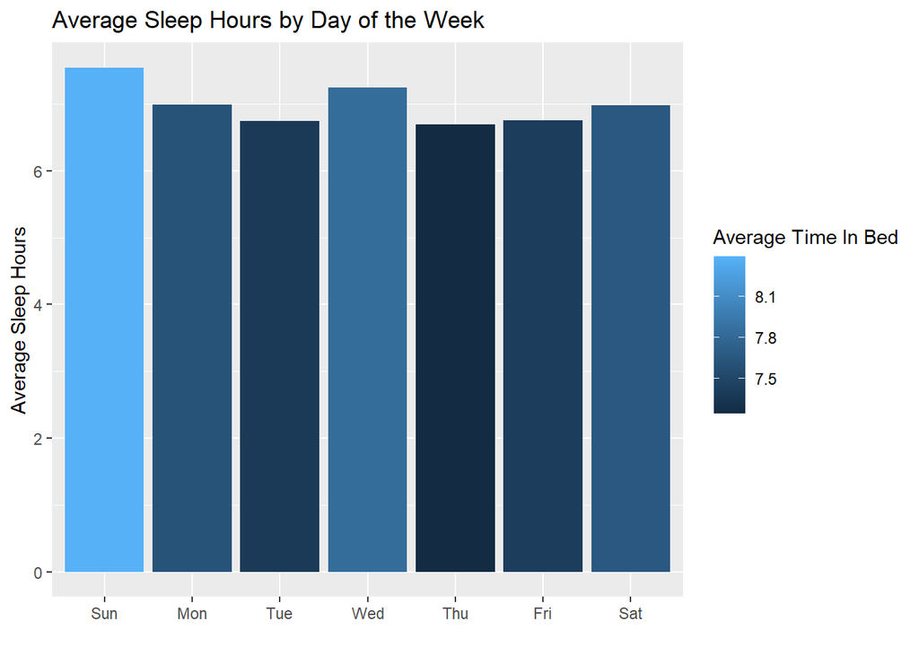

The data shows that Tuesdays and Saturdays were the best days for steps taken for the participants, both yielding an average step rate of just north of 8100. Because there is a strong correlation between steps taken and calories burned, these were also the best days for that. Sundays were they days of least steps taken at a rate of just over 6900 on average. However, even at a rate of about 7400 steps on average, Thursday yielded the lowest average calorie burn.

It also may come as no surprise that participants slept the most on Sundays, where participants slept about 7.5 hours on average. However, it is interesting to note that people also spent the most time in bed on Sundays as well, at a rate of about 51 minutes on average when not sleeping.

## Recommendations

- Increase notifications for daily step goals. General consensus is that 10,000 steps daily are a good average for people to shoot for in overall health. Aiming for people to reach this goal can be done incrementally (depending on person’s daily performance) until people feel comfortable reaching it each day. Even increasing the average of 7600 to 8500 steps per day could yield dramatic improvement to health. As Sunday is the day of most inactivity for users, it might be worth exploring pushing more notifications than usual on this day.
- Create activity programs within the app that educate and encourage an increase in activity levels, particularly on the dramatic calories burn increase that occurs between non-activity and just light activity. This could really appeal to more skeptical, non-active customers on a pragmatic level.
- Find ways to positively reinforce weight reporting daily within the app. This data is far too limited due to participant’s unwillingness to report it. This is essential for users to be fully aware of their health performance on a daily basis.